# MATH 9102 - Probability and Statistical Inference Assignment - 1

Antonio Silva (D23129331@mytudublin.ie)

```r
if ('knitr' %in% installed.packages() == FALSE) {
  install.packages('knitr', repos = 'http://cran.us.r-project.org')
}

library(knitr)
```

# 1. Understanding data (3 marks)

## Question a

Assume that you have a table with variables that describe a person, Name, age, height, weight and profession. Identify variables that are discrete, continuous, and categorical. (1 mark)

### Answer

Person

| Variable | Type |
| --- | --- |
| name | categorical |
| age | discrete |
| height | continuous |
| weight | continuous |
| profession | categorical |

## Question b

Assume that you have a table with variables that describe a lecturer. Name, gender, subject, semester, and semester, and staff number. Identify variables that are ordinal, interval, and ratio. (1 mark)

### Answer

Lecturer

| Variable | Type |
| --- | --- |
| name | nominal |
| gender | nominal |
| subject | nominal |
| semester | ordinal |
| staff number | nominal |

## Question c

You and a friend wonder if it is “normal” that some bottles of your favourite beer contain more beer than others although the volume is stated as 0.33L. You find out from the manufacturer that the volume of beer in a bottle has a mean of 0.33L and a standard deviation of 0.03. If you now measure the beer volume in the next 100 bottles that you drink with your friend, how many of those 100 bottles are expected to contain more than 0.39L given that the information of the manufacturer is correct? (1 mark)

### Answer

To solve this problem we can use the central limit theorem that states that if we take a sufficiently large samples of a population, the samples means will be normally distributed even if the population isn’t normally distributed.

So we have the given parameters:
$$x =
0.39L\ \mbox{individual value}$$
$$\mu
= 0.33L\ \mbox{mean}$$
$$\sigma =
0.03L \ \mbox{Standard deviation}$$

Now we need to calculate the $z$ score for a normal distribution.

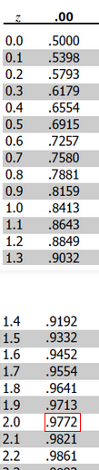

z score = 2 in a normal distribution

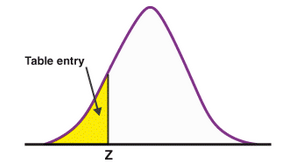

z-score definition

# 2. Descriptive statistics (6 marks)

Use the `salary.rds` dataset from the lecture 1

## Question a

Install the following packages `Hmisc`, `pastecs`, `psych`

### Answer

```r
if ('Hmisc' %in% installed.packages() == FALSE) {
  install.packages('Hmisc', repos = 'http://cran.us.r-project.org')
}

if ('pastecs' %in% installed.packages() == FALSE) {
  install.packages('pastecs', repos = 'http://cran.us.r-project.org')
}

if ('psych' %in% installed.packages() == FALSE) {
install.packages('psych', repos = 'http://cran.us.r-project.org')
}
```

## Question b

Describe the data using installed packaged and identify the differences in description by different package

### Answer

**Hmisc**

`describe` shows a summary of the data showing the *standard variation*, *median*, *quartiles* *highest* and *lowers* presenting the data as a frequency table per variable. It also shows presents a histogram if the variable is numeric.

**pastecs**

`pastec.stat` shows a table with descriptive statistics *only for numerical variables*. It presents various dispersed variables like *mean*, *median*, *variance*, *stardand variation*, *range*, *min*, *max*, It shows the *Standard Error Mean*, and the *Confidence Interfal of the Mean*.

**psych**

`describe` shows a table with the *number of sample* (discards the null values), *mean*, *median*, *trimmed mean*, *min* value, *max* value, *range*, *standard deviation*, *standand error*, it is less data than the `pastecs` package but shows the *skew* and *kurtosis* of the variables. Variables that are categorical or logical are converted to numerical and marked with a `*`

```r
library(Hmisc, warn.conflicts = FALSE)
library(pastecs, warn.conflicts = FALSE)
library(psych, warn.conflicts = FALSE)

salary<-readRDS("data/salary.rds")

description.Hmisc <- Hmisc::describe(salary)
description.pastecs <- pastecs::stat.desc(salary)
description.psych <- psych::describe(salary)

html(description.Hmisc)
```

salary  
7 Variables 52 Observations

gender

| n | missing | distinct |
| --- | --- | --- |
| 52 | 0 | 2 |

```
 Value      Female   Male
 Frequency      14     38
 Proportion  0.269  0.731
```

rank

| n | missing | distinct |
| --- | --- | --- |
| 52 | 0 | 3 |

```
 Value      Assistant Associate      Full
 Frequency         18        14        20
 Proportion     0.346     0.269     0.385
```

yr

| n | missing | distinct | Info | Mean | Gmd | .05 | .10 | .25 | .50 | .75 | .90 | .95 |
| --- | --- | --- | --- | --- | --- | --- | --- | --- | --- | --- | --- | --- |
| 52 | 0 | 18 | 0.995 | 7.481 | 6.174 | 0.55 | 1.00 | 3.00 | 7.00 | 11.00 | 14.80 | 16.00 |

```
 Value          0     1     2     3     4     5     6     7     8     9    10    11
 Frequency      3     4     4     5     4     2     2     3     3     5     3     3
 Proportion 0.058 0.077 0.077 0.096 0.077 0.038 0.038 0.058 0.058 0.096 0.058 0.058

 Value         12    13    15    16    19    25
 Frequency      1     4     1     3     1     1
 Proportion 0.019 0.077 0.019 0.058 0.019 0.019
```

For the frequency table, variable is rounded to the nearest 0

dg

| n | missing | distinct | Info | Sum | Mean | Gmd |
| --- | --- | --- | --- | --- | --- | --- |
| 52 | 0 | 2 | 0.679 | 34 | 0.6538 | 0.4615 |

exper

| n | missing | distinct | Info | Mean | Gmd | .05 | .10 | .25 | .50 | .75 | .90 | .95 |
| --- | --- | --- | --- | --- | --- | --- | --- | --- | --- | --- | --- | --- |
| 52 | 0 | 29 | 0.998 | 16.12 | 11.85 | 1.00 | 2.10 | 6.75 | 15.50 | 23.25 | 30.90 | 31.45 |

lowest : 1 2 3 4 5 , highest: 30 31 32 33 35

salary

| n | missing | distinct | Info | Mean | Gmd | .05 | .10 | .25 | .50 | .75 | .90 | .95 |
| --- | --- | --- | --- | --- | --- | --- | --- | --- | --- | --- | --- | --- |
| 52 | 0 | 51 | 1 | 23798 | 6755 | 16125 | 16519 | 18247 | 23719 | 27258 | 31903 | 34440 |

lowest : 15000 15350 16094 16150 16244 , highest: 32850 33696 35350 36350 38045

expcat

| n | missing | distinct | Info | Mean | Gmd |
| --- | --- | --- | --- | --- | --- |
| 52 | 0 | 7 | 0.972 | 3.654 | 2.327 |

```
 Value          1     2     3     4     5     6     7
 Frequency     12     4    10     7     8     5     6
 Proportion 0.231 0.077 0.192 0.135 0.154 0.096 0.115
```

For the frequency table, variable is rounded to the nearest 0

```r
kable(description.pastecs)
```

|  | gender | rank | yr | dg | exper | salary | expcat |
| --- | --- | --- | --- | --- | --- | --- | --- |
| nbr.val | NA | NA | 52.0000000 | 52.0000000 | 52.0000000 | 5.200000e+01 | 52.0000000 |
| nbr.null | NA | NA | 3.0000000 | 18.0000000 | 0.0000000 | 0.000000e+00 | 0.0000000 |
| nbr.na | NA | NA | 0.0000000 | 0.0000000 | 0.0000000 | 0.000000e+00 | 0.0000000 |
| min | NA | NA | 0.0000000 | 0.0000000 | 1.0000000 | 1.500000e+04 | 1.0000000 |
| max | NA | NA | 25.0000000 | 1.0000000 | 35.0000000 | 3.804500e+04 | 7.0000000 |
| range | NA | NA | 25.0000000 | 1.0000000 | 34.0000000 | 2.304500e+04 | 6.0000000 |
| sum | NA | NA | 389.0000000 | 34.0000000 | 838.0000000 | 1.237478e+06 | 190.0000000 |
| median | NA | NA | 7.0000000 | 1.0000000 | 15.5000000 | 2.371900e+04 | 3.5000000 |
| mean | NA | NA | 7.4807692 | 0.6538462 | 16.1153846 | 2.379765e+04 | 3.6538462 |
| SE.mean | NA | NA | 0.7637579 | 0.0666173 | 1.4175835 | 8.205804e+02 | 0.2812446 |
| CI.mean | NA | NA | 1.5333079 | 0.1337399 | 2.8459176 | 1.647384e+03 | 0.5646220 |
| var | NA | NA | 30.3329563 | 0.2307692 | 104.4962293 | 3.501431e+07 | 4.1131222 |
| std.dev | NA | NA | 5.5075363 | 0.4803845 | 10.2223397 | 5.917289e+03 | 2.0280834 |
| coef.var | NA | NA | 0.7362259 | 0.7347056 | 0.6343218 | 2.486501e-01 | 0.5550544 |

```r
kable(description.psych)
```

|  | vars | n | mean | sd | median | trimmed | mad | min | max | range | skew | kurtosis | se |
| --- | --- | --- | --- | --- | --- | --- | --- | --- | --- | --- | --- | --- | --- |
| gender* | 1 | 52 | 1.730769e+00 | 0.4478876 | 2.0 | 1.785714e+00 | 0.0000 | 1 | 2 | 1 | -1.0106614 | -0.9966271 | 0.0621108 |
| rank* | 2 | 52 | 2.038461e+00 | 0.8623165 | 2.0 | 2.047619e+00 | 1.4826 | 1 | 3 | 2 | -0.0713405 | -1.6773420 | 0.1195818 |
| yr | 3 | 52 | 7.480769e+00 | 5.5075363 | 7.0 | 7.023809e+00 | 5.9304 | 0 | 25 | 25 | 0.7468534 | 0.3085015 | 0.7637579 |
| dg | 4 | 52 | 6.538462e-01 | 0.4803845 | 1.0 | 6.904762e-01 | 0.0000 | 0 | 1 | 1 | -0.6281951 | -1.6357249 | 0.0666173 |
| exper | 5 | 52 | 1.611538e+01 | 10.2223397 | 15.5 | 1.595238e+01 | 12.6021 | 1 | 35 | 34 | 0.0728612 | -1.2024045 | 1.4175835 |
| salary | 6 | 52 | 2.379765e+04 | 5917.2891544 | 23719.0 | 2.338926e+04 | 6643.5306 | 15000 | 38045 | 23045 | 0.4476630 | -0.6010913 | 820.5803638 |
| expcat | 7 | 52 | 3.653846e+00 | 2.0280834 | 3.5 | 3.571429e+00 | 2.2239 | 1 | 7 | 6 | 0.1475296 | -1.2300702 | 0.2812446 |

## Question c

Generate summary statistics by using grouping by Gender. (1 mark)

Hint: *use package psych*

### Answer

```r
description.psych.by_gender <- psych::describeBy(salary, group=salary$gender)
render.description.psych.by_gender <- lapply(names(description.psych.by_gender),
                                             function(name){
                                               knitr::kable(description.psych.by_gender[name], caption = name)})
render.description.psych.by_gender
```

[[1]]

Female

|  | vars | n | mean | sd | median | trimmed | mad | min | max | range | skew | kurtosis | se |
| --- | --- | --- | --- | --- | --- | --- | --- | --- | --- | --- | --- | --- | --- |
| gender | 1 | 14 | 1.000000e+00 | 0.0000000 | 1.0 | 1.000000 | 0.0000 | 1 | 1 | 0 | NaN | NaN | 0.0000000 |
| rank | 2 | 14 | 1.714286e+00 | 0.9138735 | 1.0 | 1.666667 | 0.0000 | 1 | 3 | 2 | 0.5271408 | -1.666028 | 0.2442430 |
| yr | 3 | 14 | 4.071429e+00 | 3.2925157 | 3.5 | 3.916667 | 3.7065 | 0 | 10 | 10 | 0.3017713 | -1.440628 | 0.8799618 |
| dg | 4 | 14 | 7.142857e-01 | 0.4688072 | 1.0 | 0.750000 | 0.0000 | 0 | 1 | 1 | -0.8488760 | -1.361735 | 0.1252940 |
| exper | 5 | 14 | 1.464286e+01 | 12.3699832 | 14.5 | 14.250000 | 18.5325 | 1 | 33 | 32 | 0.2165690 | -1.712193 | 3.3060171 |
| salary | 6 | 14 | 2.135714e+04 | 6151.8730588 | 20495.0 | 20496.250000 | 6044.5602 | 15000 | 38045 | 23045 | 1.2600790 | 1.158610 | 1644.1572338 |
| expcat | 7 | 14 | 3.428571e+00 | 2.3766261 | 3.0 | 3.333333 | 2.9652 | 1 | 7 | 6 | 0.2899376 | -1.662958 | 0.6351800 |

[[2]]

Male

|  | vars | n | mean | sd | median | trimmed | mad | min | max | range | skew | kurtosis | se |
| --- | --- | --- | --- | --- | --- | --- | --- | --- | --- | --- | --- | --- | --- |
| gender | 1 | 38 | 2.000000e+00 | 0.0000000 | 2 | 2.00000 | 0.0000 | 2 | 2 | 0 | NaN | NaN | 0.0000000 |
| rank | 2 | 38 | 2.157895e+00 | 0.8228597 | 2 | 2.18750 | 1.4826 | 1 | 3 | 2 | -0.2841787 | -1.5059387 | 0.1334855 |
| yr | 3 | 38 | 8.736842e+00 | 5.6553453 | 9 | 8.43750 | 5.9304 | 0 | 25 | 25 | 0.5527139 | -0.0239386 | 0.9174181 |
| dg | 4 | 38 | 6.315789e-01 | 0.4888515 | 1 | 0.65625 | 0.0000 | 0 | 1 | 1 | -0.5241524 | -1.7697781 | 0.0793022 |
| exper | 5 | 38 | 1.665789e+01 | 9.4419315 | 17 | 16.59375 | 8.8956 | 1 | 35 | 34 | 0.0552071 | -1.0240824 | 1.5316836 |
| salary | 6 | 38 | 2.469679e+04 | 5646.4090246 | 24746 | 24507.62500 | 5682.8058 | 16094 | 36350 | 20256 | 0.1917805 | -0.9003976 | 915.9684963 |
| expcat | 7 | 38 | 3.736842e+00 | 1.9127483 | 4 | 3.68750 | 1.4826 | 1 | 7 | 6 | 0.0961265 | -1.0881008 | 0.3102887 |

## Question d

Load *iris* dataset into workspace.

Identify mean, median, range, 98th percentile of Petal.Length (1 mark)

### Answer

```r
petalLenght.mean <- mean(iris$Petal.Length)
petalLenght.median <- median(iris$Petal.Length)
petalLenght.range <- range(iris$Petal.Length)
petalLength.98percentile <- quantile(iris$Petal.Length, 0.98)

print(paste('Mean Petal Length:', petalLenght.mean))
```

```
## [1] "Mean Petal Length: 3.758"
```

```r
print(paste('Median Petal Length:', petalLenght.median))
```

```
## [1] "Median Petal Length: 4.35"
```

```r
print(paste('Range Petal Length min:', petalLenght.range[1], ' max:', petalLenght.range[2]))
```

```
## [1] "Range Petal Length min: 1  max: 6.9"
```

```r
print(paste('98%  Percentile Petal Length:', petalLength.98percentile))
```

```
## [1] "98%  Percentile Petal Length: 6.602"
```

## Question e

Draw the histogram for Sepal.Width, mention which measure of dispersion method suits the best? (1 mark)

### Answer

The histogram reveals a bell-shaped curve reminiscent of the normal distribution. Given the data’s normal distribution with a continuous variable, it’s advisable to utilize the mean and standard deviation. Opting for the standard deviation over the variance is preferable since it preserves the units of the variable and facilitates easier comprehension.

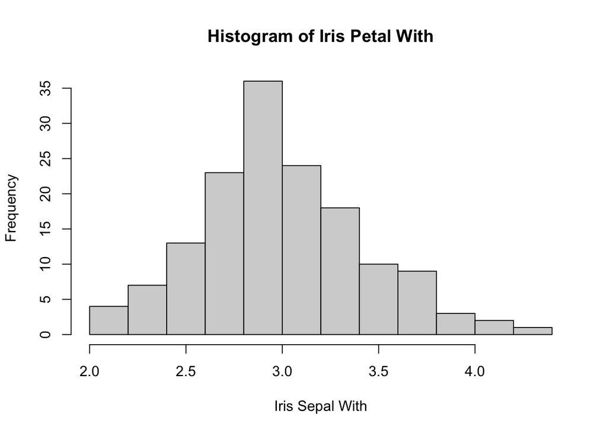

```r
hist(iris$Sepal.Width, main = 'Histogram of Iris Petal With', xlab = 'Iris Sepal With')
```

```r
sepalWidth.range <- range(iris$Sepal.Width)
sepalWidth.variance <- var(iris$Sepal.Width)
sepalWidth.sd  <- sd(iris$Sepal.Width)
sepalWidth.iqr <- IQR(iris$Petal.Width)

# Print the measures of dispersion
print(paste("Range of Sepal Width: [", sepalWidth.range[1], ',', sepalWidth.range[2], ']'))
```

```
## [1] "Range of Sepal Width: [ 2 , 4.4 ]"
```

```r
print(paste("Variance of Sepal Width:", sepalWidth.variance))
```

```
## [1] "Variance of Sepal Width: 0.189979418344519"
```

```r
print(paste("Standard Deviation of Sepal Width:", sepalWidth.sd))
```

```
## [1] "Standard Deviation of Sepal Width: 0.435866284936698"
```

```r
print(paste("Interquartile Range of Sepal Width:", sepalWidth.iqr))
```

[output not shown]

## Question f

Load *HairEyeColor* dataset into workspace.

*Hint: dataHairEye <- as.data.frame(HairEyeColor)*

As a customer, I would like to know the total number of people with various color combination of hair and eyes. Which chart suits best for this task? Plot the same. (1 mark)

### Answer

For this dataset we are counting the value of *two categorical* variables, so we need to find a way to see this two variables and how they correlate each other.

Initially, I considered a *heatmap* or a chart *count overlapping points*. However, I encountered difficulties in thoroughly examining the data.

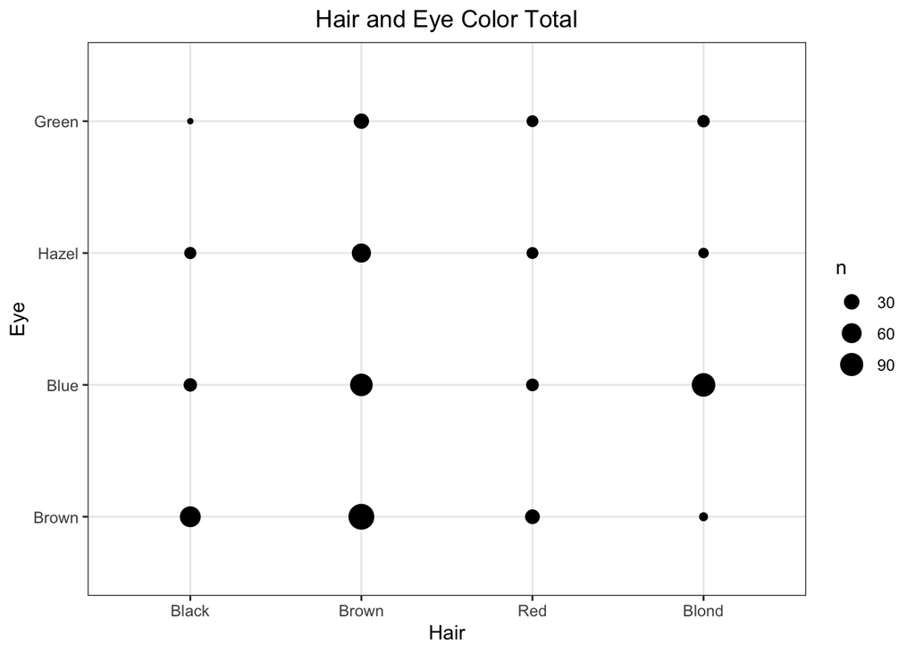

```r
if ('ggplot2' %in% installed.packages() == FALSE) {
  install.packages('ggplot2', repos = 'http://cran.us.r-project.org')
}

library(ggplot2, warn.conflicts = FALSE)

data(HairEyeColor)
dataHairEye <- as.data.frame(HairEyeColor)

ggplot(data = dataHairEye, aes(x = Hair, y=Eye, weight = Freq)) +
geom_count() + ggtitle("Hair and Eye Color Total") +
theme_bw() +
theme(plot.title = element_text(hjust = 0.5))
```

As you can observe, distinguishing between the values of “Brown Hair - Blue Eye” and “Black Hair - Brown Eye” isn’t straightforward.

Therefore, I opted for a bar plot. In this plot, hair color is represented on the *x-axis*, with each bar representing a different *eye color category value* plotted side by side on the *y-axis*.

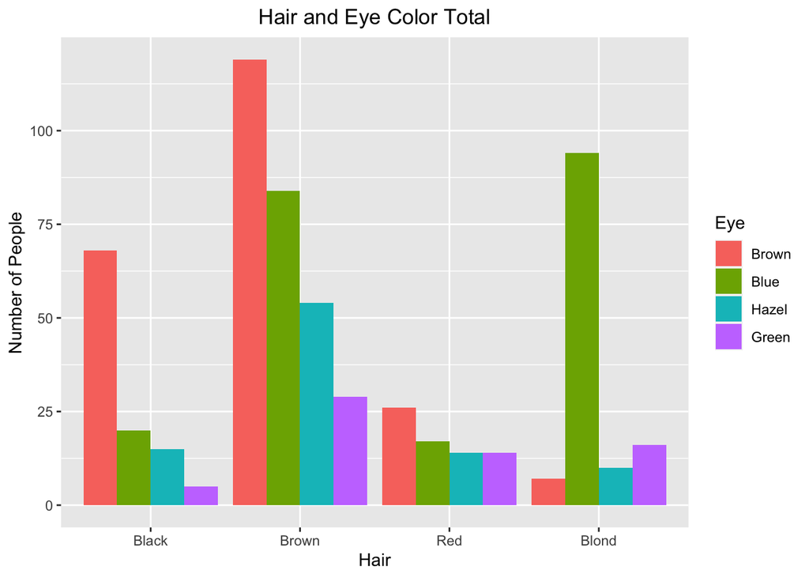

```r
ggplot(data = dataHairEye, aes(x = Hair, weight = Freq)) +
geom_bar(aes(fill = Eye), position = 'dodge') +
ggtitle("Hair and Eye Color Total") +
ylab("Number of People") +
theme(plot.title = element_text(hjust = 0.5))
```

So I think that the bar-plot chart is the best representation for this data.

# 3. Visualization (6 marks)

## Question a

A meteorologist wants to compare the annual average rain fall between two cities for the past 20 years. Which plot is most suitable? Plot the graph by generating 20 random data points between 0 and 28 for Dublin and Cork. (2 marks)

### Answer

For a dataset comprising 20 data points and aiming to compare two cities, I think that an area chart is the best one.

Employing a bar plot in this context could potentially lead to confusion due to the multitude of bars per year and per city.

Therefore, opting for an area chart would be more advantageous for comparing the categories of Dublin and Cork and visualizing their changes over time.

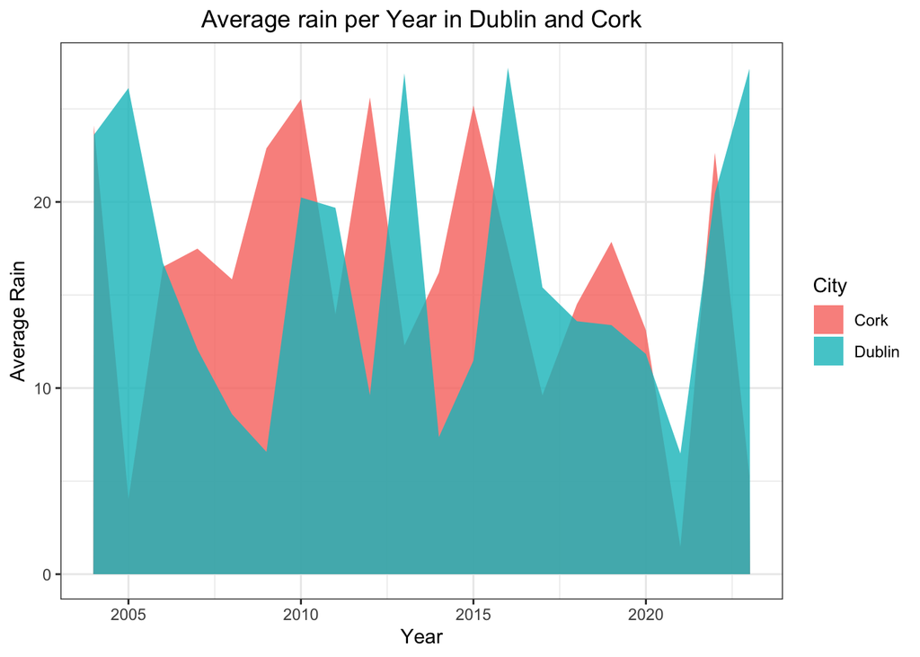

```r
 if ('tidyr' %in% installed.packages() == FALSE) {
     install.packages('tidyr', repos = 'http://cran.us.r-project.org')
 }
library(tidyr, warn.conflicts = FALSE)

current_year <- as.numeric(format(Sys.Date(), "%Y"))
rain_data <- data.frame(Year = (current_year - 20):(current_year - 1),
                        Cork = runif(20, 0, 28),
                        Dublin = runif(20, 0, 28))
df_rain_data <- gather(rain_data, City, Rain, c(Dublin,Cork))

ggplot(data=df_rain_data, aes(x = Year, fill = City)) +
  geom_area(aes(y = Rain), position = position_dodge(width = 0), alpha=0.8) +
  ylab("Average Rain") +
  ggtitle("Average rain per Year in Dublin and Cork") +
  theme_bw() +
  theme(plot.title = element_text(hjust = 0.5))
```

## Question b

Load the provided `world-small.csv` file. (2 marks)

- 1. Draw histogram for ‘gdppcap08’
- 2. Draw boxplot for ‘polityIV’
- 3. Identify the region that has highest gdpcap.
- 4. Which country has lowest polityIV?

### Answer

#### i

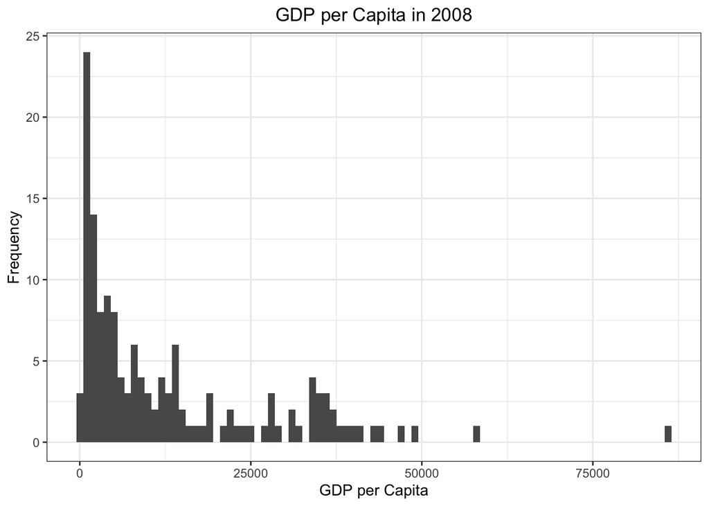

```r
df_world_small <- read.csv("data/world-small.csv", header = TRUE)

ggplot(df_world_small, aes(x = gdppcap08)) +
geom_histogram(binwidth = 1000) +
labs(title = "GDP per Capita in 2008", x = "GDP per Capita", y = "Frequency") +
theme_bw() +
theme(plot.title = element_text(hjust = 0.5))
```

#### ii

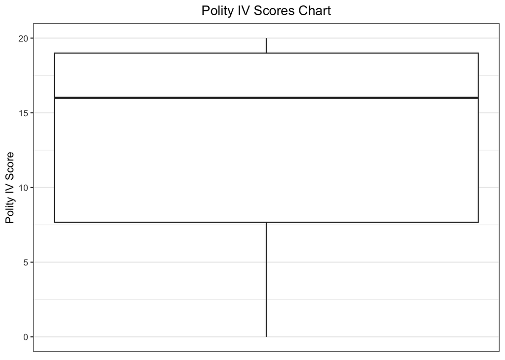

```r
ggplot(df_world_small, aes(y = polityIV)) +
  geom_boxplot() +
  labs(title = "Polity IV Scores Chart", x = "", y = "Polity IV Score") +
  theme_bw() +
  theme(plot.title = element_text(hjust = 0.5),
    axis.title.x=element_blank(),
    axis.text.x=element_blank(),
    axis.ticks.x=element_blank(),
    panel.grid.major.x = element_blank(),
    panel.grid.minor.x = element_blank())
```

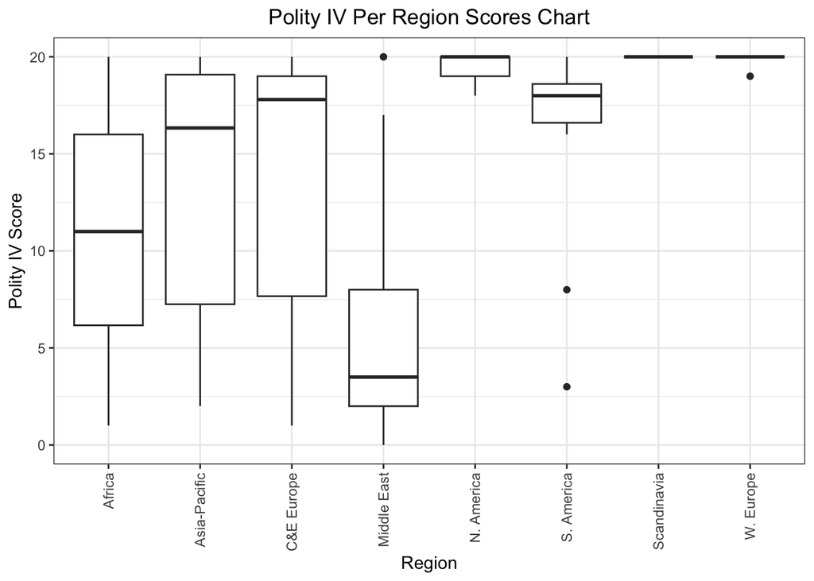

```r
ggplot(df_world_small, aes(y = polityIV, x = region)) +
  geom_boxplot() +
  labs(title = "Polity IV Per Region Scores Chart", x = "Region", y = "Polity IV Score") +
  theme_bw() +
  theme(plot.title = element_text(hjust = 0.5),
    axis.text.x = element_text(angle = 90, vjust = 0.5, hjust=1))
```

#### iii

To find the region with the biggest GDP per Capita we need to do the following - 1. we need to find the maximum value and the corresponding index `which.max(df_world_small$gdppcap08)` - 2. select the row `df_world_small[which.max(df_world_small$gdppcap08), ]` - 3. filter the column region `df_world_small[which.max(df_world_small$gdppcap08), "region"]`

```r
region_biggest_gdpcap08 <- df_world_small[which.max(df_world_small$gdppcap08), "region"]
print(region_biggest_gdpcap08)
```

```
## [1] "Middle East"
```

#### iv

To find the country with the lowest polityIV Index we need to do the following steps:

- 1. we need to find the minimum polityIV value and the corresponding index `which.min(df_world_small$polityIV)`
- 2. select the row `df_world_small[which.min(df_world_small$polityIV), ]`
- 3. filter the column country `df_world_small[which.min(df_world_small$polityIV), "country"]`

To find *all* the countries with the lowest polityIV Index we need to do the following steps:

- 1. we need to find the minimum polityIV value `min(df_world_small$polityIV)`
- 2. filter all the values corresponding to the value `df_world_small$polityIV == min(df_world_small$polityIV)`
- 3. select the corresponding rows `df_world_small[df_world_small$polityIV == min(df_world_small$polityIV), ]`
- 4. filter the column country `df_world_small[df_world_small$polityIV == min(df_world_small$polityIV), "country"]`

```r
country_with_min_polityiv <- df_world_small[which.min(df_world_small$polityIV), "country"]
countries_with_min_polityiv <- df_world_small[df_world_small$polityIV == min(df_world_small$polityIV), "country"]

print(country_with_min_polityiv)
```

```
## [1] "Qatar"
```

```r
print(countries_with_min_polityiv)
```

```
## [1] "Qatar"        "Saudi Arabia"
```

## Question c

Table 1 represents people in Dublin who like to own certain types of pets. (2 marks)

Table 1: Pet Lovers

| Pet | Number of people |
| --- | --- |
| Dogs | 2034 |
| Cats | 492 |
| Fish | 785 |
| Macaw | 298 |

- 1. Plot the most suitable graph for the given dataset.
- 2. Is it a good idea to choose a pie chart (in case you have not chosen it in (i))? Why is it a good idea or why is it not a good idea?

### Answer

#### i

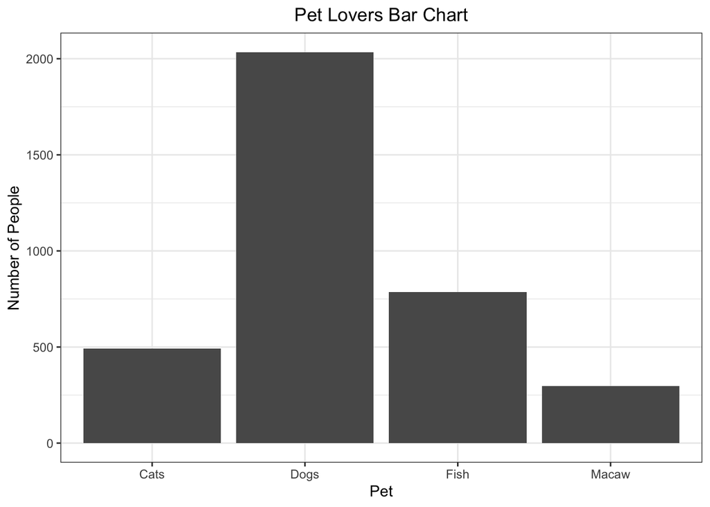

```r
pets_text <- "Pet Number_of_people
              Dogs  2034
              Cats  492
              Fish  785
              Macaw 298"

df_pets <- read.table(text = pets_text, header = TRUE)

ggplot(data = df_pets, aes(x = Pet, y = Number_of_people)) +
   geom_bar(stat = "identity") +
   labs(title = "Pet Lovers Bar Chart", x = "Pet", y = "Number of People") +
   theme_bw() +
   theme(plot.title = element_text(hjust = 0.5))
```

#### ii

Looking at the pie chart of pets, I find it challenging to discern and compare the number of individuals who favor each type of pet. In my opinion, a pie chart is more effective for representing proportions rather than absolute values.

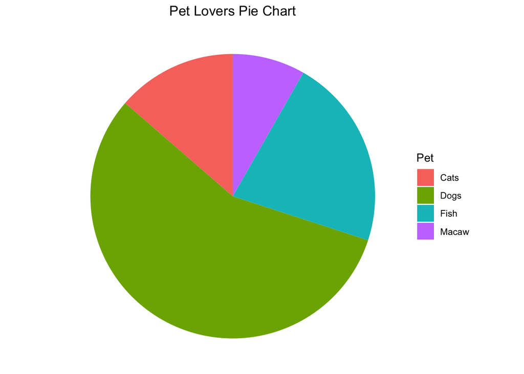

```r
ggplot(data = df_pets, aes(x ="" , y = Number_of_people, fill = Pet)) +
  geom_bar(stat = "identity", width = 1) +
  coord_polar("y", start=0) +
  labs(title = "Pet Lovers Pie Chart") +
  theme_bw() +
  theme_void() +
  theme(plot.title = element_text(hjust = 0.5))
```